# Graphics and Data Visualization

Pablo Barbera, Dan Cervone

January 20, 2016

We’ve already seen the `plot` function; there are a few other base `R` functions for quickly and easily displaying data.

```r
drivers <- read.csv("./bad-drivers.csv")
names(drivers) # variable names are too long!
```

```
## [1] "State"
## [2] "Number.of.drivers.involved.in.fatal.collisions.per.billion.miles"
## [3] "Percentage.Of.Drivers.Involved.In.Fatal.Collisions.Who.Were.Speeding"
## [4] "Percentage.Of.Drivers.Involved.In.Fatal.Collisions.Who.Were.Alcohol.Impaired"
## [5] "Percentage.Of.Drivers.Involved.In.Fatal.Collisions.Who.Were.Not.Distracted"
## [6] "Percentage.Of.Drivers.Involved.In.Fatal.Collisions.Who.Had.Not.Been.Involved.In.Any.Previous.Accidents"
## [7] "Car.Insurance.Premiums...."
## [8] "Losses.incurred.by.insurance.companies.for.collisions.per.insured.driver...."
```

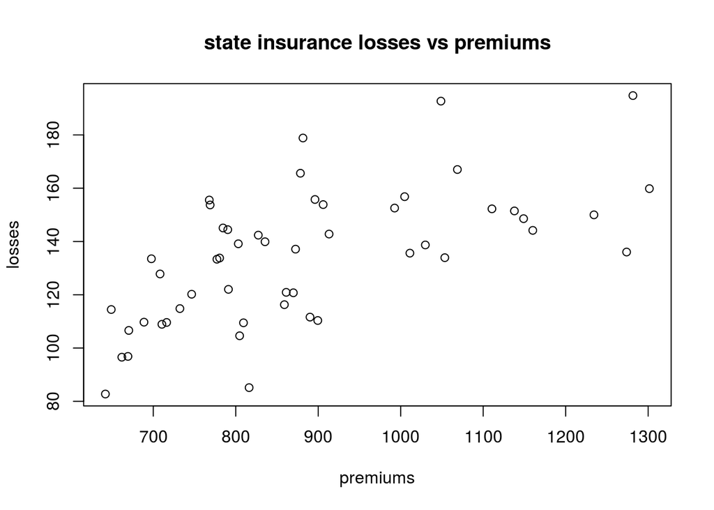

```r
names(drivers) <- c("state", "fatal", "speeding",
                    "alcohol", "not.distracted", "no.prev",
                    "premium", "losses")
plot(drivers$premium, drivers$losses, xlab="premiums", ylab="losses", main="state insurance losses vs premiums")
```

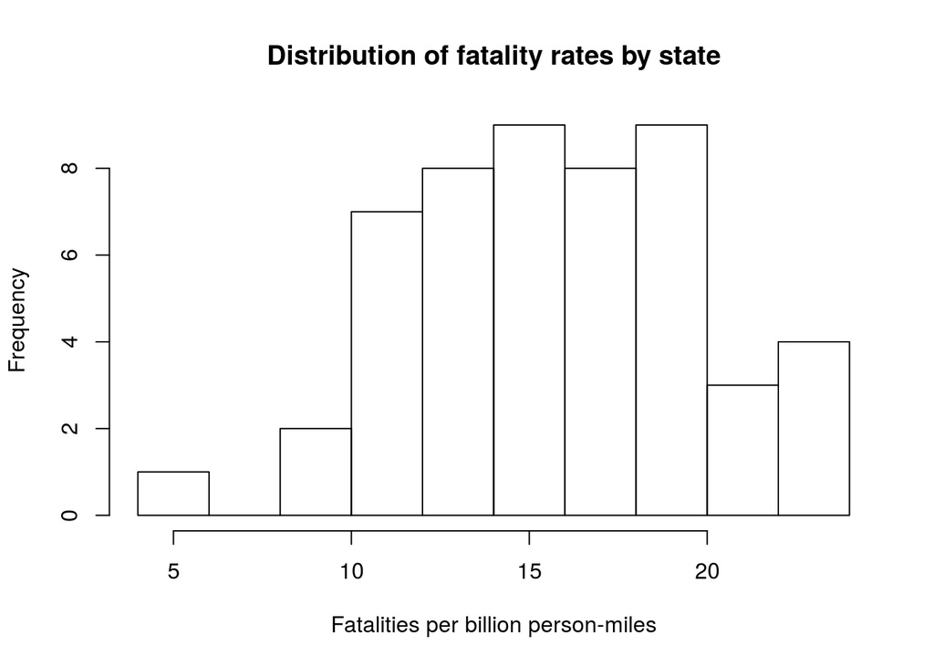

```r
hist(drivers$fatal, xlab="Fatalities per billion person-miles", main="Distribution of fatality rates by state")
```

Functions like `plot` and `hist` are great for quickly displaying data, and are incredibly helpful throughout data exploration. Yet these graphics are not very aesthetic, and are limited in the quantity and media of information conveyed. While there are many methods in base `R` to build on these types of graphics, an alternative and very popular graphics library for `R` is the package `ggplot2` (which we already installed).

### Quick Plots

`qplot` stands for “quick plot” and behaves very similarly to base `R`’s `plot`. However, it is straightforward to add layers of information.

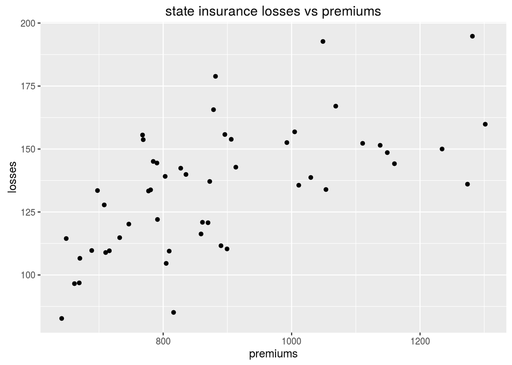

```r
library(ggplot2)
qplot(premium, losses, data=drivers, xlab="premiums", ylab="losses", main="state insurance losses vs premiums")
```

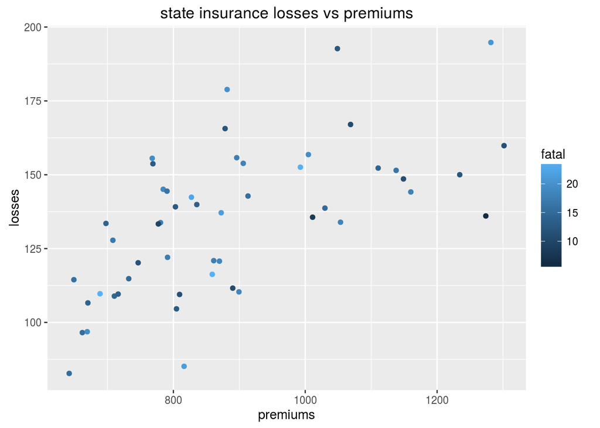

```r
qplot(premium, losses, data=drivers, xlab="premiums", ylab="losses", main="state insurance losses vs premiums", color=fatal)
```

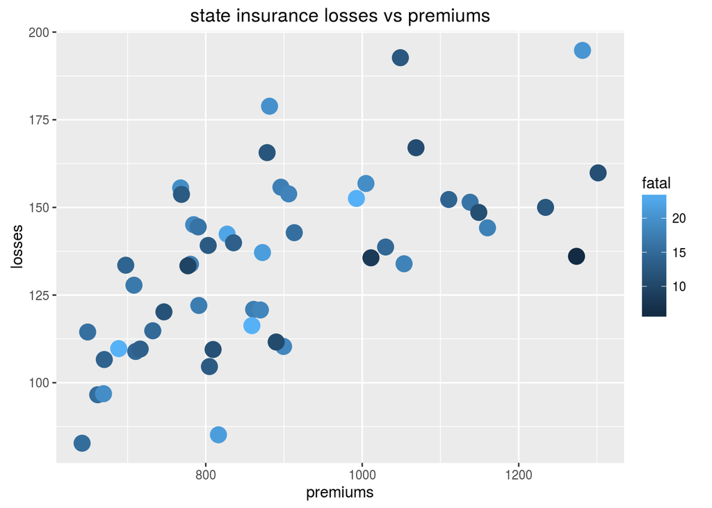

```r
qplot(premium, losses, data=drivers, xlab="premiums", ylab="losses", main="state insurance losses vs premiums", color=fatal, size=I(5))
```

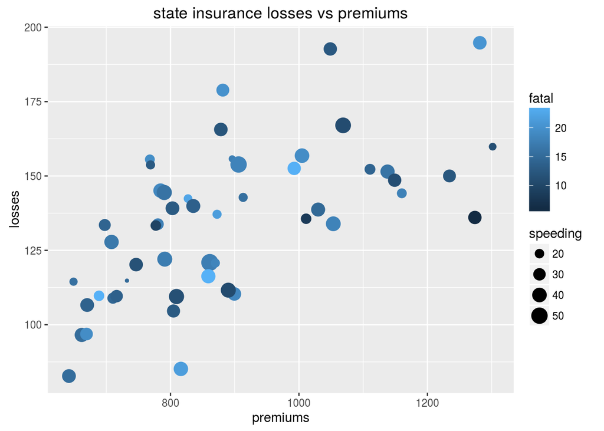

```r
qplot(premium, losses, data=drivers, xlab="premiums", ylab="losses", main="state insurance losses vs premiums", color=fatal, size=speeding)
```

### Mappings

Full functionality of `ggplot2` revolves around the concept of aesthetic mappings, which describe how data are represented visually in a graph or map. We can redo the above analysis using some of these ideas.

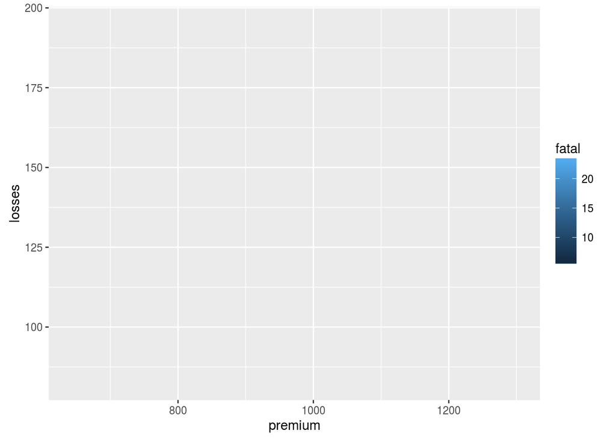

```r
myplot <- ggplot(data=drivers,
                 mapping=aes(premium, losses, color=fatal, size=speeding))
myplot # hmm....
```

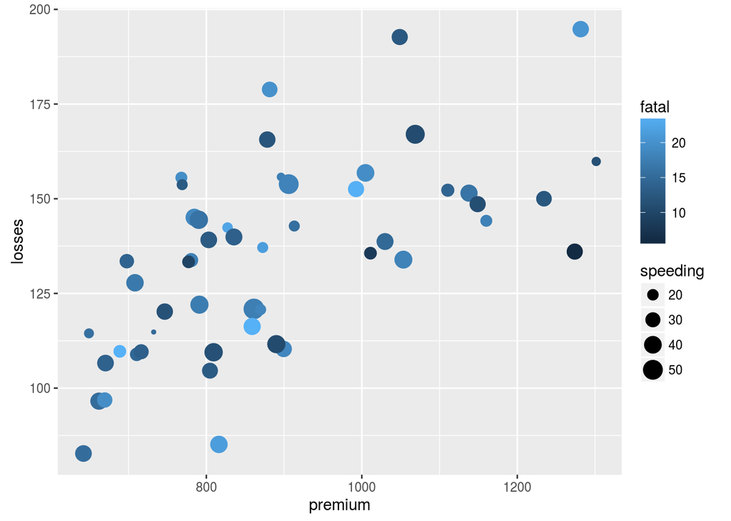

```r
myplot + geom_point() # add layers with "+"
```

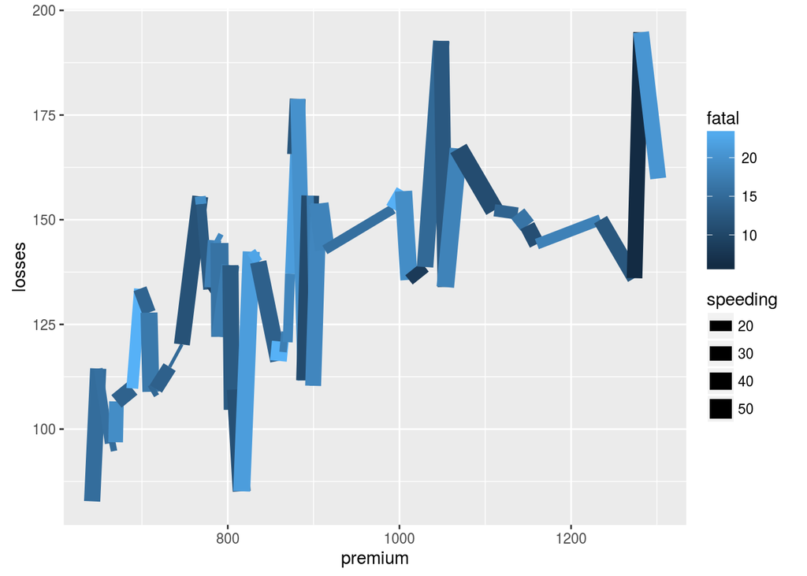

```r
myplot + geom_line() # looks cool but meaningless?
```

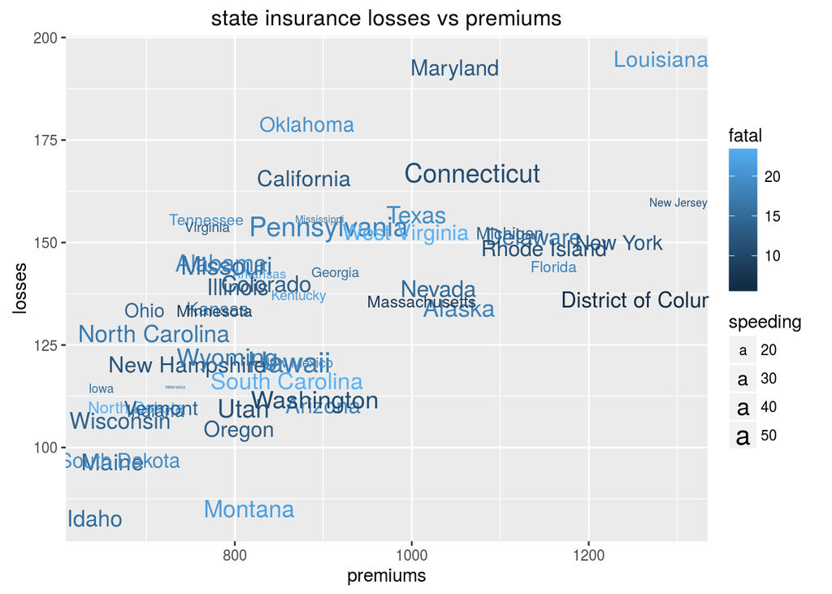

```r
textplot <- myplot + labs(x="premiums", y="losses") +
  ggtitle("state insurance losses vs premiums") +
  geom_text(mapping=aes(premium, losses, label=state), data=drivers)
textplot # something different
```

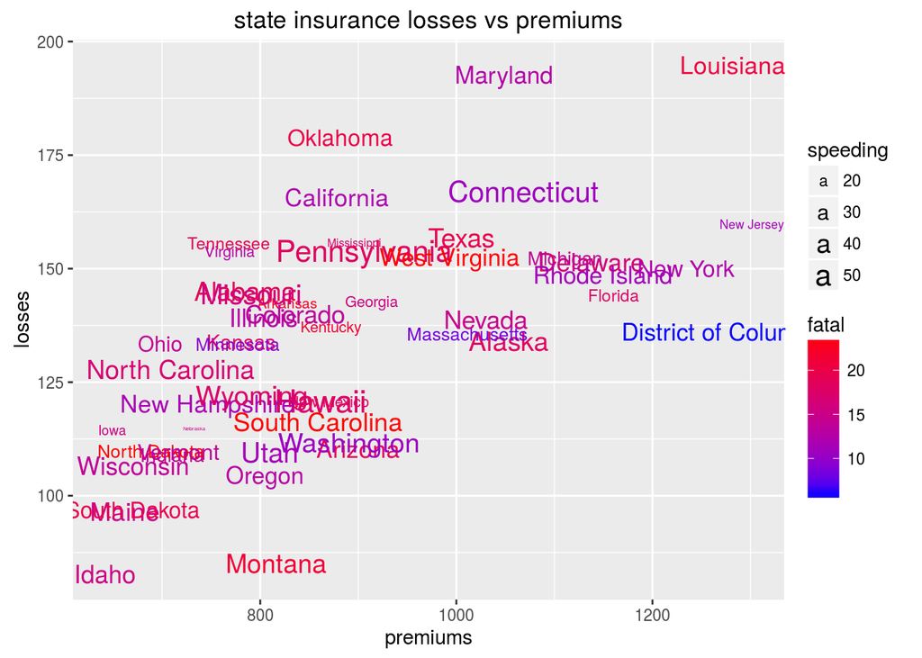

```r
textplot + scale_color_gradient(low="blue", high="red") # different colors
```

### Geographical data

We can plot maps of geographical regions, such as the US, and overlay state-specific data. First, to get a map of the US looking nice, we can do:

```r
install.packages("maps", repos="http://cran.rstudio.com")
states <- map_data("state") # long/lat information for all states
head(states)
```

```
##        long      lat group order  region subregion
## 1 -87.46201 30.38968     1     1 alabama      <NA>
## 2 -87.48493 30.37249     1     2 alabama      <NA>
## 3 -87.52503 30.37249     1     3 alabama      <NA>
## 4 -87.53076 30.33239     1     4 alabama      <NA>
## 5 -87.57087 30.32665     1     5 alabama      <NA>
## 6 -87.58806 30.32665     1     6 alabama      <NA>
```

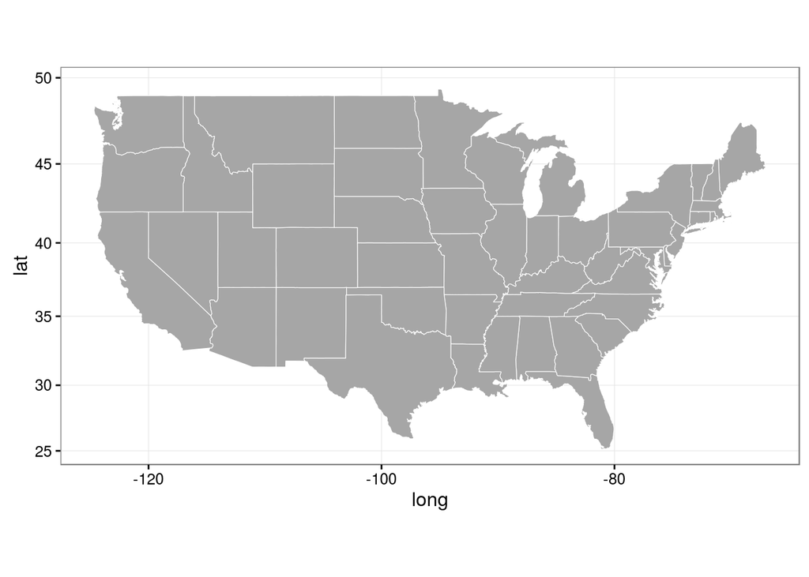

```r
statemap <- ggplot(states, aes(x=long, y=lat, group=group)) +
  geom_polygon(fill="grey65", color="white", size = 0.2) + # state colors/borders
  theme_bw() + # no background grid
  coord_map("mercator") # flat projection from sphere of US area
statemap
```

Let’s use this as a foundation to plot some of the variables in the drivers data, to see if there are any geographical trends. First, note that the `states` data set uses lowercase letters only for states in the `region` variable, so let’s modify the drivers data to include a lowercase `region` variable for easy cross referencing.

```r
drivers$region <- tolower(drivers$state) # region variable is automatically added
states_drivers <- merge(states, drivers, by="region")
head(states_drivers)
```

```
##    region      long      lat group order subregion   state fatal speeding
## 1 alabama -87.46201 30.38968     1     1      <NA> Alabama  18.8       39
## 2 alabama -87.48493 30.37249     1     2      <NA> Alabama  18.8       39
## 3 alabama -87.52503 30.37249     1     3      <NA> Alabama  18.8       39
## 4 alabama -87.53076 30.33239     1     4      <NA> Alabama  18.8       39
## 5 alabama -87.57087 30.32665     1     5      <NA> Alabama  18.8       39
## 6 alabama -87.58806 30.32665     1     6      <NA> Alabama  18.8       39
##   alcohol not.distracted no.prev premium losses
## 1      30             96      80  784.55 145.08
## 2      30             96      80  784.55 145.08
## 3      30             96      80  784.55 145.08
## 4      30             96      80  784.55 145.08
## 5      30             96      80  784.55 145.08
## 6      30             96      80  784.55 145.08
```

Now that the driving statistics are part of the states data set, we can incorporate them as layers in our states map.

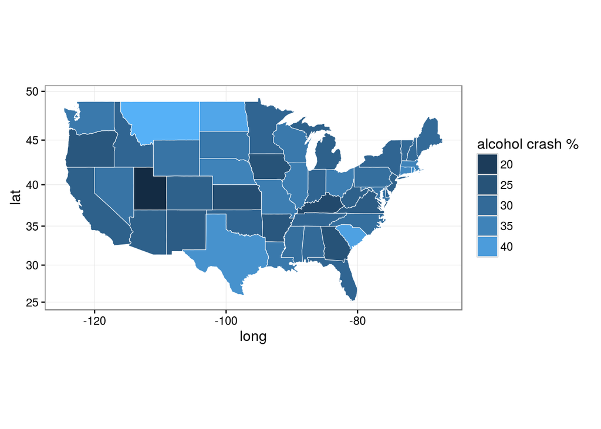

```r
statemap <- ggplot(states_drivers, aes(x=long, y=lat, group=group, fill=alcohol)) +
  geom_polygon(color="white", size = 0.2) +
  theme_bw() +
  guides(fill=guide_legend(title="alcohol crash %")) +
  coord_map("mercator")
statemap
```